# train_cnn

## Training script for the CNN

Loads in the converted plane representation of the pgn files, defines the network architecture and starts the training process. Checkpoints of the weights are saved if there's an improvement in the validation loss. The training performance metrics (e.g. losses, accuracies...) are exported to tensorboard and can be checked during training.

- author: QueensGambit

```python
%load_ext autoreload
%autoreload 2
```

```python
%reload_ext autoreload
```

```python
from __future__ import print_function
import os
import sys
sys.path.insert(0,'../../../')
import glob
import chess
import shutil
import logging
import numpy as np
from pathlib import Path
from copy import deepcopy

from DeepCrazyhouse.src.training.train_util import get_metrics, prepare_policy, value_to_wdl_label, prepare_plys_label
from DeepCrazyhouse.src.domain.variants.input_representation import board_to_planes, planes_to_board
from DeepCrazyhouse.src.domain.variants.output_representation import policy_to_moves, policy_to_best_move, policy_to_move
from DeepCrazyhouse.src.preprocessing.dataset_loader import load_pgn_dataset
from DeepCrazyhouse.src.runtime.color_logger import enable_color_logging
from DeepCrazyhouse.configs.main_config import main_config
from DeepCrazyhouse.configs.train_config import TrainConfig, TrainObjects

from DeepCrazyhouse.src.training.lr_schedules.lr_schedules import *
from DeepCrazyhouse.src.domain.variants.plane_policy_representation import FLAT_PLANE_IDX
from DeepCrazyhouse.src.domain.variants.constants import NB_POLICY_MAP_CHANNELS, NB_LABELS, MODE_CHESS, MODE_CRAZYHOUSE
enable_color_logging()
%matplotlib inline
```

```
2023-11-20 08:54:53 matplotlib.pyplot[492] DEBUG Loaded backend module://matplotlib_inline.backend_inline version unknown.
2023-11-20 08:54:53 matplotlib.pyplot[492] DEBUG Loaded backend module://matplotlib_inline.backend_inline version unknown.
```

```python
tc = TrainConfig()
to = TrainObjects()
# Decide between 'pytorch', 'mxnet' and 'gluon' style for training
tc.framework: str = 'pytorch'
```

### pytorch imports

```python
if tc.framework == 'pytorch':
    import torch
    from torch.utils.data import TensorDataset, DataLoader
    from torchsummary import summary
    from fvcore.nn import FlopCountAnalysis

    from DeepCrazyhouse.src.training.trainer_agent_pytorch import TrainerAgentPytorch, save_torch_state,\
    load_torch_state, export_to_onnx, get_context, get_data_loader, evaluate_metrics
    # architectures
    from DeepCrazyhouse.src.domain.neural_net.architectures.pytorch.rise_mobile_v3 import RiseV3, get_rise_v33_model_by_train_config
    from DeepCrazyhouse.src.domain.neural_net.architectures.pytorch.vision_transformer import VisionTransformer
    from DeepCrazyhouse.src.domain.neural_net.architectures.pytorch.vit_configs import get_b8_config
    from DeepCrazyhouse.src.domain.neural_net.architectures.pytorch.le_vit import LeViT
    from DeepCrazyhouse.src.domain.neural_net.architectures.pytorch.mobile_vit import MobileViT
    from DeepCrazyhouse.src.domain.neural_net.architectures.pytorch.trt_vit import TrtViT
    from DeepCrazyhouse.src.domain.neural_net.architectures.pytorch.next_vit_official import NextVit
    from DeepCrazyhouse.src.domain.neural_net.architectures.pytorch.a0_resnet import AlphaZeroResnet
    from DeepCrazyhouse.src.domain.neural_net.architectures.pytorch.a0_nbrn import AlphaZeroNBRN
    # Test
```

### mxnet imports

```python
if tc.framework == 'mxnet' or tc.framework == 'gluon':
    import mxnet as mx
    from mxnet import nd
    from mxnet import gluon
    try:
        import mxnet.metric as metric
    except ModuleNotFoundError:
        import mxnet.gluon.metric as metrics

    from DeepCrazyhouse.src.training.trainer_agent_gluon import TrainerAgentGluon, evaluate_metrics, acc_sign, get_data_loader
    from DeepCrazyhouse.src.training.trainer_agent_mxnet import TrainerAgentMXNET, get_context
    # architectures
    from DeepCrazyhouse.src.domain.neural_net.architectures.a0_resnet import AlphaZeroResnet
    from DeepCrazyhouse.src.domain.neural_net.architectures.mxnet_alpha_zero import alpha_zero_symbol
    from DeepCrazyhouse.src.domain.neural_net.architectures.rise_mobile_v2 import rise_mobile_v2_symbol
    from DeepCrazyhouse.src.domain.neural_net.architectures.rise_mobile_v3 import rise_mobile_v3_symbol
    from DeepCrazyhouse.src.domain.neural_net.architectures.preact_resnet_se import preact_resnet_se
    from DeepCrazyhouse.src.domain.neural_net.onnx.convert_to_onnx import convert_mxnet_model_to_onnx
```

## Settings

```python
# set the context on CPU, switch to GPU if there is one available (strongly recommended for training)
tc.context = "gpu"
tc.device_id = 0

# set a specific seed value for reproducibility
tc.seed = 7 # 42

tc.export_weights = True
tc.log_metrics_to_tensorboard = True
tc.export_grad_histograms = False

# directory to write and read weights, logs, onnx and other export files
tc.export_dir = "./"

tc.div_factor = 1  # div factor is a constant which can be used to reduce the batch size and learning rate respectively
# use a value greater 1 if you encounter memory allocation errors

# batch_steps = 1000 means for example that every 1000 batches the validation set gets processed
tc.batch_steps = 1000 * tc.div_factor # this defines how often a new checkpoint will be saved and the metrics evaluated
# k_steps_initial defines how many steps have been trained before
# (k_steps_initial != 0 if you continue training from a checkpoint)
tc.k_steps_initial = 0
# these are the weights to continue training with
tc.symbol_file = None # 'model-0.81901-0.713-symbol.json'
tc.params_file = None #'model-0.81901-0.713-0498.params'

tc.batch_size = int(1024 / tc.div_factor) # 1024 # the batch_size needed to be reduced to 1024 in order to fit in the GPU 1080Ti
#4096 was originally used in the paper -> works slower for current GPU
# 2048 was used in the paper Mastering the game of Go without human knowledge and fits in GPU memory
#typically if you half the batch_size, you should double the lr

# optimization parameters
tc.optimizer_name = "nag"  # "adam" "adamw" #
if tc.framework == 'pytorch':
    # strangely pytorch should use a different lr than mxnet
    tc.max_lr = 0.07 / tc.div_factor
else:
    tc.max_lr = 0.35 / tc.div_factor #0.01 # default lr for adam
tc.min_lr = 0.00001

if "adam" in tc.optimizer_name:
    tc.max_lr = 0.001001 #1e-3
    tc.min_lr = 0.001

tc.max_momentum = 0.95
tc.min_momentum = 0.8
# loads a previous checkpoint if the loss increased significanly
tc.use_spike_recovery = True
# stop training as soon as max_spikes has been reached
tc.max_spikes = 20
# define spike threshold when the detection will be triggered
tc.spike_thresh = 1.5
# weight decay
tc.wd = 1e-4
tc.dropout_rate = 0 #0.15

# enables training with a wdl head as intermediate target (mainly useful for environments with 3 outcomes)
tc.use_wdl = True
# enables training with ply to end head
tc.use_plys_to_end = True
# adds a small mlp to infer the value loss from wdl and plys_to_end_output
tc.use_mlp_wdl_ply = False

# weight the value loss a lot lower than the policy loss in order to prevent overfitting
tc.val_loss_factor = 0.01
tc.policy_loss_factor = 0.988 if tc.use_plys_to_end else 0.99
tc.plys_to_end_loss_factor = 0.002
tc.wdl_loss_factor = 0.01
tc.discount = 1.0

tc.normalize = True # define whether to normalize input data to [0,1]
tc.nb_training_epochs = 7 # define how many epochs the network will be trained
tc.select_policy_from_plane = True # Boolean if potential legal moves will be selected from final policy output

# additional custom validation set files which will be logged to tensorboard
to.variant_metrics = None # ["chess960", "koth", "three_check"]
# if use_extra_variant_input is true the current active variant is passed two each residual block and

# ratio for mixing the value return with the corresponding q-value
# for a ratio of 0 no q-value information will be used
tc.q_value_ratio = 0

# define if policy training target is one-hot encoded a distribution (e.g. mcts samples, knowledge distillation)
tc.sparse_policy_label = True
# define if the policy data is also defined in "select_policy_from_plane" representation
tc.is_policy_from_plane_data = False
tc.name_initials = "JC"
```

```python
mode = main_config["mode"]
ctx = get_context(tc.context, tc.device_id)
# concatenated at the end of the final feature representation
use_extra_variant_input = False
cur_it = tc.k_steps_initial * tc.batch_steps # iteration counter used for the momentum and learning rate schedule
```

```python
if tc.framework == 'mxnet' or tc.framework == 'gluon':
    # Fixing the random seed
    mx.random.seed(tc.seed)
    mx.__version__
```

### Create logs and weights directory

```python
if not os.path.exists(tc.export_dir + "logs"):
    os.mkdir(tc.export_dir + "logs")
if not os.path.exists(tc.export_dir + "weights"):
    os.mkdir(tc.export_dir + "weights")
```

### Show the config files

```python
print(main_config)
```

```
{'pgn_train_dir': '/data/pgn/train/', 'pgn_val_dir': '/data/pgn/val/', 'pgn_test_dir': '/data/pgn/test/', 'pgn_mate_in_one_dir': '/data/pgn/mate_in_one/', 'planes_train_dir': '/data/SL/train/', 'planes_val_dir': '/data/SL/val/', 'planes_test_dir': '/data/SL/test/', 'planes_mate_in_one_dir': '/data/S…
```

```python
print(tc)
```

```
TrainConfig(div_factor=1, batch_size=1024, batch_steps=1000, context='gpu', cpu_count=4, device_id=0, discount=1.0, dropout_rate=0, export_dir='./', export_weights=True, export_grad_histograms=False, framework='pytorch', is_policy_from_plane_data=False, log_metrics_to_tensorboard=True, k_steps_initi…
```

```python
print(to)
```

```
TrainObjects()
```

### Validation Dataset (which is used during training)

```python
s_idcs_val, x_val, yv_val, yp_val, plys_to_end, pgn_datasets_val = load_pgn_dataset(dataset_type='val', part_id=0,
                                                                           verbose=True, normalize=tc.normalize)
if tc.discount != 1:
    yv_val *= tc.discount**plys_to_end

if tc.framework == 'mxnet':
    if tc.select_policy_from_plane:
        if tc.use_wdl and tc.use_wdl:
            val_iter = mx.io.NDArrayIter({'data': x_val},
                                         {'value_label': yv_val,
                                          'policy_label': np.array(FLAT_PLANE_IDX)[yp_val.argmax(axis=1)],
                                          'wdl_label': value_to_wdl_label(yv_val),
                                          'plys_to_end_label': prepare_plys_label(plys_to_end)},
                                          tc.batch_size)
        else:
            val_iter = mx.io.NDArrayIter({'data': x_val},
                                         {'value_label': yv_val,
                                          'policy_label': np.array(FLAT_PLANE_IDX)[yp_val.argmax(axis=1)]},
                                         tc.batch_size)
    else:
        val_iter = mx.io.NDArrayIter({'data': x_val}, {'value_label': yv_val, 'policy_label': yp_val.argmax(axis=1)}, tc.batch_size)
elif tc.framework == 'gluon' or tc.framework == 'pytorch':
    val_data = get_data_loader(x_val, yv_val, yp_val, plys_to_end, tc, shuffle=False)
```

```
2023-11-20 08:54:54 root[492] DEBUG loading: /data/SL/val/2021-01-12-14-14-24/lichess_db_crazyhouse_rated_2018-04_0.zip ...
2023-11-20 08:54:54 root[492] DEBUG
2023-11-20 08:54:55 root[492] INFO STATISTICS:
black_wins [444]
draws [2]
game_idx_end [1000]
game_idx_start [0]
number_selected_games [1000]
white_wins [554]
2023-11-20 08:54:55 root[492] INFO PARAMETERS:
batch_size [1000]
compression [b'lz4']
limit_nb_games [0]
max_nb_files [1]
min_elo_both [2000]
pgn_name [b'lichess_db_crazyhouse_rated_2018-04.pgn']
termination_conditions [b'Normal']
```

```python
tc.nb_parts = len(glob.glob(main_config['planes_train_dir'] + '**/*'))
```

```python
nb_it_per_epoch = (len(x_val) * tc.nb_parts) // tc.batch_size # calculate how many iterations per epoch exist
# one iteration is defined by passing 1 batch and doing backprop
tc.total_it = int(nb_it_per_epoch * tc.nb_training_epochs)
tc.total_it
```

```
9436
```

### Define a Learning Rate schedule

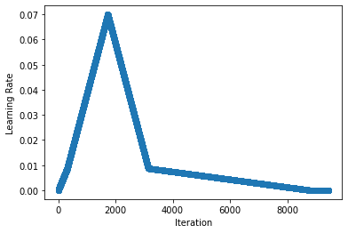

```python
if "adam" in tc.optimizer_name:
    to.lr_schedule = ConstantSchedule(tc.min_lr)
else:
    to.lr_schedule = OneCycleSchedule(start_lr=tc.max_lr/8, max_lr=tc.max_lr, cycle_length=tc.total_it*.3, cooldown_length=tc.total_it*.6, finish_lr=tc.min_lr)
to.lr_schedule = LinearWarmUp(to.lr_schedule, start_lr=tc.min_lr, length=tc.total_it/30)

logging.getLogger().setLevel(logging.WARNING)
plot_schedule(to.lr_schedule, iterations=tc.total_it)
logging.getLogger().setLevel(logging.DEBUG)
```

### Momentum schedule

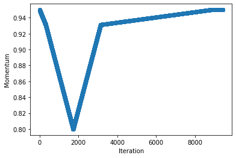

```python
to.momentum_schedule = MomentumSchedule(to.lr_schedule, tc.min_lr, tc.max_lr, tc.min_momentum, tc.max_momentum)
plot_schedule(to.momentum_schedule, iterations=tc.total_it, ylabel='Momentum')
```

### Create the model

```python
input_shape = x_val[0].shape
input_shape
```

```
(34, 8, 8)
```

```python
try:
    del net
except:
    pass
```

### Define the NN model / Load the pretrained model

### MXNet model definitions

```python
symbol = None
```

```python
#net = AlphaZeroResnet(n_labels=2272, channels=256, channels_value_head=8, channels_policy_head=81, num_res_blocks=19, value_fc_size=256, bn_mom=0.9, act_type='relu', select_policy_from_plane=select_policy_from_plane)
```

```python
#net = alpha_zero_resnet(n_labels=2272, channels=256, channels_value_head=1, channels_policy_head=81, num_res_blocks=19, value_fc_size=256, bn_mom=0.9, act_type='relu')
```

```python
#symbol = alpha_zero_symbol(num_filter=256, channels_value_head=4, channels_policy_head=81, workspace=1024, value_fc_size=256, num_res_blocks=19, bn_mom=0.9, act_type='relu',
#                            n_labels=2272, grad_scale_value=0.01, grad_scale_policy=0.99, select_policy_from_plane=select_policy_from_plane)
```

```python
#bc_res_blocks = [3] * 13
#if tc.symbol_file is None:
#    symbol = rise_mobile_v2_symbol(channels=256, channels_operating_init=128, channel_expansion=64, channels_value_head=8,
#                      channels_policy_head=NB_POLICY_MAP_CHANNELS, value_fc_size=256, bc_res_blocks=bc_res_blocks, res_blocks=[], act_type='relu',
#                      n_labels=NB_LABELS, grad_scale_value=tc.val_loss_factor, grad_scale_policy=tc.policy_loss_factor, select_policy_from_plane=tc.select_policy_from_plane,
#                      use_se=True, dropout_rate=tc.dropout_rate, use_extra_variant_input=use_extra_variant_input)
#else:
#    symbol = mx.sym.load(tc.export_dir + "weights/" + tc.symbol_file)
```

kernels = [3] * 15 kernels[7] = 5 kernels[11] = 5 kernels[12] = 5 kernels[13] = 5

se_types = [None] * len(kernels) se_types[5] = "eca_se" se_types[8] = "eca_se" se_types[12] = "eca_se" se_types[13] = "eca_se" se_types[14] = "eca_se"

kernels = [3] * 7

se_types = [None] * len(kernels) se_types[5] = "eca_se"

symbol = rise_mobile_v3_symbol(channels=256, channels_operating_init=224, channel_expansion=32, act_type='relu', channels_value_head=8, value_fc_size=256, channels_policy_head=NB_POLICY_MAP_CHANNELS, grad_scale_value=tc.val_loss_factor, grad_scale_policy=tc.policy_loss_factor, grad_scale_wdl=tc.wdl_loss_factor, grad_scale_ply=tc.plys_to_end_loss_factor, dropout_rate=tc.dropout_rate, select_policy_from_plane=True, kernels=kernels, se_types=se_types, use_avg_features=False, use_wdl=tc.use_wdl, use_plys_to_end=tc.use_plys_to_end, use_mlp_wdl_ply=tc.use_mlp_wdl_ply )

kernels = [3,3,3,3,3,3,5,5]

se_types = [ None, # 1 None, # 2 None, # 3 "eca_se", # 4 None, # 5 None, # 6 None, # 7 "eca_se", # 8 ]

symbol = preact_resnet_se(channels=288, act_type='relu', channels_value_head=8, value_fc_size=256, channels_policy_head=NB_POLICY_MAP_CHANNELS, grad_scale_value=tc.val_loss_factor, grad_scale_policy=tc.policy_loss_factor, dropout_rate=tc.dropout_rate, select_policy_from_plane=True, kernels=kernels, se_types=se_types, use_avg_features=True, use_raw_features=True)

### Pytorch model definitions

```python
model = AlphaZeroNBRN(
    nb_input_channels=input_shape[0], board_height=input_shape[1], board_width=input_shape[2],
                channels=256, act_type='relu', num_res_blocks=19,
                channels_value_head=8, value_fc_size=256,
                channels_policy_head=NB_POLICY_MAP_CHANNELS,
                select_policy_from_plane=tc.select_policy_from_plane,
                n_labels=NB_LABELS,
                use_wdl=tc.use_wdl, use_plys_to_end=tc.use_plys_to_end, use_mlp_wdl_ply=tc.use_mlp_wdl_ply
    )
#model = get_rise_v33_model_by_train_config(input_shape, tc)
```

model = LeViT( image_size = input_shape[1], in_channels = input_shape[0], channels_policy_head = NB_POLICY_MAP_CHANNELS, stages = 1, # number of stages dim = (256,), # dimensions at each stage depth = 9, # transformer of depth 4 at each stage heads = (4,), # heads at each stage mlp_mult = 2, dropout = 0.1, select_policy_from_plane=tc.select_policy_from_plane, use_wdl=tc.use_wdl, use_plys_to_end=tc.use_plys_to_end, use_mlp_wdl_ply=tc.use_mlp_wdl_ply,  
)

model = MobileViT( image_size = (input_shape[1], input_shape[2]), in_channels = input_shape[0], dims = [96, 120, 144], channels = 256, channels_policy_head = NB_POLICY_MAP_CHANNELS, select_policy_from_plane=tc.select_policy_from_plane, use_wdl=tc.use_wdl, use_plys_to_end=tc.use_plys_to_end, use_mlp_wdl_ply=tc.use_mlp_wdl_ply, )

model = TrtViT( image_size = input_shape[1], in_channels = input_shape[0], channels_policy_head = NB_POLICY_MAP_CHANNELS, channels=256, select_policy_from_plane=tc.select_policy_from_plane, use_wdl=tc.use_wdl, use_plys_to_end=tc.use_plys_to_end, use_mlp_wdl_ply=tc.use_mlp_wdl_ply,  
)

kernels = [3] * 12 #15 kernels[10] = 5 kernels[9] = 5 kernels[5] = 5

# kernels[13] = 5

use_transformers = [False] * len(kernels) use_transformers[11] = True

# use_transformers[9] = True

# use_transformers[4] = True

se_types = [None] * len(kernels) se_types[5] = "eca_se" se_types[11] = "eca_se"

# se_types[12] = "eca_se"

# se_types[13] = "eca_se"

# se_types[14] = "eca_se"

class Args: pass

args = Args() args.input_shape = input_shape args.channels_policy_head = NB_POLICY_MAP_CHANNELS args.n_labels = NB_LABELS args.select_policy_from_plane = tc.select_policy_from_plane args.use_wdl = tc.use_wdl args.use_plys_to_end = tc.use_plys_to_end args.use_mlp_wdl_ply = tc.use_mlp_wdl_ply

model = RiseV3(nb_input_channels=args.input_shape[0], board_height=args.input_shape[1], board_width=args.input_shape[2], channels=256, channels_operating_init=224, channel_expansion=32, channels_value_head=8, value_fc_size=256, channels_policy_head=args.channels_policy_head, dropout_rate=0, select_policy_from_plane=args.select_policy_from_plane, kernels=kernels, se_types=se_types, use_avg_features=False, n_labels=args.n_labels, use_wdl=args.use_wdl, use_plys_to_end=args.use_plys_to_end, use_mlp_wdl_ply=args.use_mlp_wdl_ply, use_transformers=use_transformers, path_dropout=0.07 )

model = NextVit( image_size = input_shape[1], in_channels = input_shape[0], channels_policy_head = NB_POLICY_MAP_CHANNELS, stage3_repeat=1, channels=256, select_policy_from_plane=tc.select_policy_from_plane, use_wdl=tc.use_wdl, use_plys_to_end=tc.use_plys_to_end, use_mlp_wdl_ply=tc.use_mlp_wdl_ply, use_transformer_heads=False, #True, se_type=None, #'eca_se' use_simple_transformer_blocks=False, #True ) # -> 19 pool blocks

model = AlphaZeroResnet(nb_input_channels=input_shape[0], board_height=input_shape[1], board_width=input_shape[2], channels=256, act_type='relu', num_res_blocks=19, channels_value_head=8, value_fc_size=256, channels_policy_head=NB_POLICY_MAP_CHANNELS, select_policy_from_plane=tc.select_policy_from_plane, n_labels=NB_LABELS, use_wdl=tc.use_wdl, use_plys_to_end=tc.use_plys_to_end, use_mlp_wdl_ply=tc.use_mlp_wdl_ply, )

model = VisionTransformer(get_b8_config(), img_size=8, in_channels=input_shape[0], num_classes=NB_POLICY_MAP_CHANNELS*64, use_wdl=tc.use_wdl, use_plys_to_end=tc.use_plys_to_end, use_mlp_wdl_ply=tc.use_mlp_wdl_ply,)

### Convert MXNet Symbol to Gluon Network

```python
if tc.framework == 'gluon' and symbol is not None:
    inputs = mx.sym.var('data', dtype='float32')
    value_out = symbol.get_internals()[main_config['value_output']+'_output']
    policy_out = symbol.get_internals()[main_config['policy_output']+'_output']
    sym = mx.symbol.Group([value_out, policy_out])
    net = mx.gluon.SymbolBlock(sym, inputs)
```

## Network summary

```python
if tc.framework == 'gluon':
    print(net)
elif tc.framework == 'pytorch':
    print(model)
```

```
AlphaZeroNBRN(
  (body): Sequential(
    (0): _Stem(
      (body): Sequential(
        (0): Conv2d(34, 256, kernel_size=(3, 3), stride=(1, 1), padding=(1, 1), bias=False)
        (1): BatchNorm2d(256, eps=1e-05, momentum=0.1, affine=True, track_running_stats=True)
        (2): ReLU(inplace=True)
      )
    )
    (1): NestedBottleNeckResidualBlock(
      (inConv): Conv2d(256, 128, kernel_size=(1, 1), stride=(1, 1))
      (outConv): Conv2d(128, 256, kernel_size=(1, 1), stride=(1, 1))
      (bnormhalfc): BatchNorm2d(128, eps=1e-05, momentum=0.1, affine=True, track_running_stats=True)
      (bnormc): BatchNorm2d(256, eps=1e-05, momentum=0.1, affine=True, track_running_stats=True)
      (act): ReLU(inplace=True)
      (intermediate_block): IntermediateResidualBlock(
        (conv): Conv2d(128, 128, kernel_size=(3, 3), stride=(1, 1), padding=(1, 1))
        (bnorm): BatchNorm2d(128, eps=1e-05, momentum=0.1, affine=True, track_running_stats=True)
        (act): ReLU(inplace=True)
      )
      (body): Sequential(
        (0): Conv2d(256, 128, kernel_size=(1, 1), stride=(1, 1))
        (1): BatchNorm2d(128, eps=1e-05, momentum=0.1, affine=True, track_running_stats=True)
        (2): ReLU(inplace=True)
        (3): IntermediateResidualBlock(
          (conv): Conv2d(128, 128, kernel_size=(3, 3), stride=(1, 1), padding=(1, 1))
          (bnorm): BatchNorm2d(128, eps=1e-05, momentum=0.1, affine=True, track_running_stats=True)
          (act): ReLU(inplace=True)
        )
        (4): IntermediateResidualBlock(
          (conv): Conv2d(128, 128, kernel_size=(3, 3), stride=(1, 1), padding=(1, 1))
          (bnorm): BatchNorm2d(128, eps=1e-05, momentum=0.1, affine=True, track_running_stats=True)
          (act): ReLU(inplace=True)
        )
        (5): Conv2d(128, 256, kernel_size=(1, 1), stride=(1, 1))
        (6): BatchNorm2d(256, eps=1e-05, momentum=0.1, affine=True, track_running_stats=True)
        (7): ReLU(inplace=True)
      )
    )
    (2): NestedBottleNeckResidualBlock(
```

[output cut: 554 more lines]

```
      (0): Linear(in_features=512, out_features=256, bias=True)
      (1): ReLU(inplace=True)
      (2): Linear(in_features=256, out_features=1, bias=True)
      (3): Tanh()
    )
  )
  (policy_head): _PolicyHead(
    (body): Sequential(
      (0): Conv2d(256, 256, kernel_size=(3, 3), stride=(1, 1), padding=(1, 1), bias=False)
      (1): BatchNorm2d(256, eps=1e-05, momentum=0.1, affine=True, track_running_stats=True)
      (2): ReLU(inplace=True)
      (3): Conv2d(256, 81, kernel_size=(3, 3), stride=(1, 1), padding=(1, 1), bias=False)
    )
  )
)
```

```python
if tc.framework != 'pytorch' and symbol is not None:
    display(mx.viz.plot_network(
        symbol,
        shape={'data':(1, input_shape[0], input_shape[1], input_shape[2])},
        node_attrs={"shape":"oval","fixedsize":"false"}
    ))
elif tc.framework == 'gluon':
    display(mx.viz.plot_network(
        net(mx.sym.var('data'))[1],
        shape={'data':(1, input_shape[0], input_shape[1], input_shape[2])},
        node_attrs={"shape":"oval","fixedsize":"false"}
    ))
```

```python
if tc.framework == 'mxnet':
    mx.viz.print_summary(
        symbol,
        shape={'data':(1, input_shape[0], input_shape[1], input_shape[2])},
    )
elif tc.framework == 'gluon':
    mx.viz.print_summary(
    net(mx.sym.var('data'))[1],
    shape={'data':(1, input_shape[0], input_shape[1], input_shape[2])},
    )
elif tc.framework == 'pytorch':
    summary(model, (input_shape[0], input_shape[1], input_shape[2]), device="cpu")
```

```
----------------------------------------------------------------
        Layer (type)               Output Shape         Param #
================================================================
            Conv2d-1            [-1, 256, 8, 8]          78,336
       BatchNorm2d-2            [-1, 256, 8, 8]             512
              ReLU-3            [-1, 256, 8, 8]               0
             _Stem-4            [-1, 256, 8, 8]               0
            Conv2d-5            [-1, 128, 8, 8]          32,896
            Conv2d-6            [-1, 128, 8, 8]          32,896
       BatchNorm2d-7            [-1, 128, 8, 8]             256
       BatchNorm2d-8            [-1, 128, 8, 8]             256
              ReLU-9            [-1, 128, 8, 8]               0
             ReLU-10            [-1, 128, 8, 8]               0
           Conv2d-11            [-1, 128, 8, 8]         147,584
           Conv2d-12            [-1, 128, 8, 8]         147,584
      BatchNorm2d-13            [-1, 128, 8, 8]             256
      BatchNorm2d-14            [-1, 128, 8, 8]             256
             ReLU-15            [-1, 128, 8, 8]               0
             ReLU-16            [-1, 128, 8, 8]               0
           Conv2d-17            [-1, 128, 8, 8]         147,584
           Conv2d-18            [-1, 128, 8, 8]         147,584
      BatchNorm2d-19            [-1, 128, 8, 8]             256
      BatchNorm2d-20            [-1, 128, 8, 8]             256
             ReLU-21            [-1, 128, 8, 8]               0
             ReLU-22            [-1, 128, 8, 8]               0
IntermediateResidualBlock-23            [-1, 128, 8, 8]               0
IntermediateResidualBlock-24            [-1, 128, 8, 8]               0
           Conv2d-25            [-1, 128, 8, 8]         147,584
           Conv2d-26            [-1, 128, 8, 8]         147,584
      BatchNorm2d-27            [-1, 128, 8, 8]             256
      BatchNorm2d-28            [-1, 128, 8, 8]             256
             ReLU-29            [-1, 128, 8, 8]               0
             ReLU-30            [-1, 128, 8, 8]               0
           Conv2d-31            [-1, 128, 8, 8]         147,584
           Conv2d-32            [-1, 128, 8, 8]         147,584
      BatchNorm2d-33            [-1, 128, 8, 8]             256
      BatchNorm2d-34            [-1, 128, 8, 8]             256
             ReLU-35            [-1, 128, 8, 8]               0
             ReLU-36            [-1, 128, 8, 8]               0
IntermediateResidualBlock-37            [-1, 128, 8, 8]               0
```

[output cut: 791 more lines]

```
          Conv2d-829            [-1, 256, 8, 8]         589,824
     BatchNorm2d-830            [-1, 256, 8, 8]             512
            ReLU-831            [-1, 256, 8, 8]               0
          Conv2d-832             [-1, 81, 8, 8]         186,624
     _PolicyHead-833                 [-1, 5184]               0
================================================================
Total params: 25,865,748
Trainable params: 25,865,748
Non-trainable params: 0
----------------------------------------------------------------
Input size (MB): 0.01
Forward/backward pass size (MB): 62.72
Params size (MB): 98.67
Estimated Total Size (MB): 161.39
----------------------------------------------------------------
```

## Analyze the Flops

```python
if tc.framework == 'pytorch':
    dummy_input = torch.Tensor(np.expand_dims(x_val[0], axis=0)).to('cpu')
    flops = FlopCountAnalysis(model, dummy_input)
    print(flops.total())
    from fvcore.nn import flop_count_table
    print(flop_count_table(flops))
```

```
2023-11-20 08:54:57 fvcore.nn.jit_analysis[492] WARNING Unsupported operator aten::add_ encountered 117 time(s)
2023-11-20 08:54:57 fvcore.nn.jit_analysis[492] WARNING Unsupported operator aten::add encountered 58 time(s)
2023-11-20 08:54:57 fvcore.nn.jit_analysis[492] WARNING Unsupported operator aten::sigmoid encountered 1 time(s)
2023-11-20 08:54:57 fvcore.nn.jit_analysis[492] WARNING Unsupported operator aten::softmax encountered 1 time(s)
2023-11-20 08:54:57 fvcore.nn.jit_analysis[492] WARNING Unsupported operator aten::neg encountered 1 time(s)
2023-11-20 08:54:57 fvcore.nn.jit_analysis[492] WARNING The following submodules of the model were never called during the trace of the graph. They may be unused, or they were accessed by direct calls to .forward() or via other python methods. In the latter case they will have zeros for statistics, …
value_head.body_final, value_head.body_final.0, value_head.body_final.1, value_head.body_final.2, value_head.body_final.3
857371136
| module                           | #parameters or shape   | #flops     |
|:---------------------------------|:-----------------------|:-----------|
| model                            | 5.068M                 | 0.857G     |
|  body                            |  4.155M                |  0.807G    |
|   body.0.body                    |   78.848K              |   5.095M   |
|    body.0.body.0                 |    78.336K             |    5.014M  |
|    body.0.body.1                 |    0.512K              |    81.92K  |
|   body.1                         |   0.215M               |   42.23M   |
|    body.1.inConv                 |    32.896K             |    2.097M  |
|    body.1.outConv                |    33.024K             |    2.097M  |
|    body.1.bnormhalfc             |    0.256K              |    40.96K  |
|    body.1.bnormc                 |    0.512K              |    81.92K  |
|    body.1.intermediate_block     |    0.148M              |    37.913M |
|   body.2                         |   0.215M               |   42.23M   |
|    body.2.inConv                 |    32.896K             |    2.097M  |
|    body.2.outConv                |    33.024K             |    2.097M  |
|    body.2.bnormhalfc             |    0.256K              |    40.96K  |
|    body.2.bnormc                 |    0.512K              |    81.92K  |
|    body.2.intermediate_block     |    0.148M              |    37.913M |
|   body.3                         |   0.215M               |   42.23M   |
|    body.3.inConv                 |    32.896K             |    2.097M  |
|    body.3.outConv                |    33.024K             |    2.097M  |
|    body.3.bnormhalfc             |    0.256K              |    40.96K  |
|    body.3.bnormc                 |    0.512K              |    81.92K  |
|    body.3.intermediate_block     |    0.148M              |    37.913M |
|   body.4                         |   0.215M               |   42.23M   |
|    body.4.inConv                 |    32.896K             |    2.097M  |
|    body.4.outConv                |    33.024K             |    2.097M  |
|    body.4.bnormhalfc             |    0.256K              |    40.96K  |
|    body.4.bnormc                 |    0.512K              |    81.92K  |
|    body.4.intermediate_block     |    0.148M              |    37.913M |
|   body.5                         |   0.215M               |   42.23M   |
```

[output cut: 95 more lines]

```
|    value_head.body_wdl.0.bias    |    (3,)                |            |
|   value_head.body_plys.0         |   0.513K               |   0.512K   |
|    value_head.body_plys.0.weight |    (1, 512)            |            |
|    value_head.body_plys.0.bias   |    (1,)                |            |
|   value_head.body_final          |   0.132M               |            |
|    value_head.body_final.0       |    0.131M              |            |
|    value_head.body_final.2       |    0.257K              |            |
|  policy_head.body                |  0.777M                |  49.775M   |
|   policy_head.body.0             |   0.59M                |   37.749M  |
|    policy_head.body.0.weight     |    (256, 256, 3, 3)    |            |
|   policy_head.body.1             |   0.512K               |   81.92K   |
|    policy_head.body.1.weight     |    (256,)              |            |
|    policy_head.body.1.bias       |    (256,)              |            |
|   policy_head.body.3             |   0.187M               |   11.944M  |
|    policy_head.body.3.weight     |    (81, 256, 3, 3)     |            |
```

## Initialize the weights

(only needed if no pretrained weights are used)

```python
if tc.framework == 'mxnet':
    # create a trainable module on compute context
    if tc.use_wdl and tc.use_plys_to_end:
        label_names=['value_label', 'policy_label', 'wdl_label', 'plys_to_end_label']
    else:
        label_names=['value_label', 'policy_label']

    model = mx.mod.Module(symbol=symbol, context=ctx, label_names=label_names)
    model.bind(for_training=True, data_shapes=[('data', (tc.batch_size, input_shape[0], input_shape[1], input_shape[2]))],
             label_shapes=val_iter.provide_label)
    model.init_params(mx.initializer.Xavier(rnd_type='uniform', factor_type='avg', magnitude=2.24))
    if tc.params_file:
        model.load_params(tc.export_dir + "weights/" + tc.params_file)
elif tc.framework == 'gluon':
    # Initializing the parameters
    for param in net.collect_params('.*gamma|.*moving_mean|.*moving_var'):
        net.params[param].initialize(mx.initializer.Constant(1), ctx=ctx)
    for param in net.collect_params('.*beta|.*bias'):
        net.params[param].initialize(mx.initializer.Constant(0), ctx=ctx)
    for param in net.collect_params('.*weight'):
        net.params[param].initialize(mx.init.Xavier(rnd_type='uniform', factor_type='avg', magnitude=2.24), ctx=ctx)

    if tc.params_file:
        net.collect_params().load(tc.export_dir + "weights/" + tc.params_file, ctx)
    net.hybridize()
elif tc.framework == 'pytorch':
    def init_weights(m):
        if isinstance(m, torch.nn.Linear) or isinstance(m, torch.nn.Conv2d):
            torch.nn.init.xavier_uniform_(m.weight)
            if isinstance(m, torch.nn.Linear):
                m.bias.data.fill_(0.01)
    #model.apply(init_weights)
    if torch.cuda.is_available():
        model.cuda(torch.device(f"cuda:{tc.device_id}"))
```

## Define the metrics to use

```python
to.metrics = get_metrics(tc)
```

## Define a training agent

```python
if tc.framework == 'mxnet':
    train_agent = TrainerAgentMXNET(model, symbol, val_iter, tc, to, use_rtpt=True)
elif tc.framework == 'gluon':
    train_agent = TrainerAgentGluon(net, val_data, tc, to, use_rtpt=True)
elif tc.framework == 'pytorch':
    train_agent = TrainerAgentPytorch(model, val_data, tc, to, use_rtpt=True)
```

## Performance Pre-Training

```python
if tc.framework == 'mxnet':
    print(model.score(val_iter, to.metrics))
```

## Start the training process

```python
(k_steps_final, value_loss_final, policy_loss_final, value_acc_sign_final, val_p_acc_final), \
    (k_steps_best, val_metric_values_best) = train_agent.train(cur_it)
```

```
2023-11-20 08:54:58 root[492] INFO EPOCH 1
2023-11-20 08:54:58 root[492] INFO =========================
```

```
2023-11-20 09:01:48 root[492] INFO Step 1K/9K - 409ms/step
2023-11-20 09:01:48 root[492] INFO -------------------------
2023-11-20 09:01:48 root[492] DEBUG Iteration 1000/9436
2023-11-20 09:01:48 root[492] DEBUG lr: 0.0384129 - momentum: 0.8676964
 - train_loss: 1.9436 - train_value_loss: 0.8348 - train_policy_loss: 1.9548 - train_value_acc_sign: 0.6557 - train_policy_acc: 0.4505 - train_wdl_loss: 0.6448 - train_wdl_acc: 0.6509 - train_plys_to_end_loss: 0.0327 - val_loss: 2.2646 - val_value_loss: 0.9277 - val_policy_loss: 2.2781 - val_value_a…
2023-11-20 09:01:59 root[492] INFO Saved checkpoint to weights/model-2.26460-0.380-0001.tar
```

```
 - 428s
2023-11-20 09:04:44 root[492] INFO EPOCH 2
2023-11-20 09:04:44 root[492] INFO =========================
```

```
2023-11-20 09:08:53 root[492] INFO Step 2K/9K - 249ms/step
2023-11-20 09:08:53 root[492] INFO -------------------------
2023-11-20 09:08:53 root[492] DEBUG Iteration 2000/9436
2023-11-20 09:08:53 root[492] DEBUG lr: 0.0583131 - momentum: 0.8250469
 - train_loss: 1.8127 - train_value_loss: 0.8960 - train_policy_loss: 1.8219 - train_value_acc_sign: 0.6193 - train_policy_acc: 0.4777 - train_wdl_loss: 0.6520 - train_wdl_acc: 0.6180 - train_plys_to_end_loss: 0.0287 - val_loss: 2.0478 - val_value_loss: 0.9419 - val_policy_loss: 2.0590 - val_value_a…
2023-11-20 09:09:04 root[492] INFO Saved checkpoint to weights/model-2.04783-0.419-0002.tar
 - 268s
2023-11-20 09:14:25 root[492] INFO EPOCH 3
2023-11-20 09:14:25 root[492] INFO =========================
```

```
2023-11-20 09:15:59 root[492] INFO Step 3K/9K - 93ms/step
2023-11-20 09:15:59 root[492] INFO -------------------------
2023-11-20 09:15:59 root[492] DEBUG Iteration 3000/9436
2023-11-20 09:15:59 root[492] DEBUG lr: 0.0150392 - momentum: 0.9177901
 - train_loss: 1.8222 - train_value_loss: 0.8098 - train_policy_loss: 1.8324 - train_value_acc_sign: 0.6688 - train_policy_acc: 0.4720 - train_wdl_loss: 0.6129 - train_wdl_acc: 0.6661 - train_plys_to_end_loss: 0.0266 - val_loss: 1.9524 - val_value_loss: 0.8781 - val_policy_loss: 1.9633 - val_value_a…
2023-11-20 09:16:09 root[492] INFO Saved checkpoint to weights/model-1.95241-0.442-0003.tar
 - 112s
2023-11-20 09:23:04 root[492] INFO Step 4K/9K - 405ms/step
2023-11-20 09:23:04 root[492] INFO -------------------------
2023-11-20 09:23:04 root[492] DEBUG Iteration 4000/9436
2023-11-20 09:23:04 root[492] DEBUG lr: 0.0074306 - momentum: 0.9340964
 - train_loss: 1.7111 - train_value_loss: 0.7654 - train_policy_loss: 1.7207 - train_value_acc_sign: 0.6958 - train_policy_acc: 0.4955 - train_wdl_loss: 0.5762 - train_wdl_acc: 0.6942 - train_plys_to_end_loss: 0.0338 - val_loss: 1.8423 - val_value_loss: 0.8445 - val_policy_loss: 1.8524 - val_value_a…
2023-11-20 09:23:15 root[492] INFO Saved checkpoint to weights/model-1.84228-0.462-0004.tar
 - 425s
2023-11-20 09:24:26 root[492] INFO EPOCH 4
2023-11-20 09:24:26 root[492] INFO =========================
```

```
2023-11-20 09:30:07 root[492] INFO Step 5K/9K - 341ms/step
2023-11-20 09:30:07 root[492] INFO -------------------------
2023-11-20 09:30:07 root[492] DEBUG Iteration 5000/9436
2023-11-20 09:30:07 root[492] DEBUG lr: 0.0058869 - momentum: 0.9374049
 - train_loss: 1.4985 - train_value_loss: 0.8382 - train_policy_loss: 1.5052 - train_value_acc_sign: 0.6561 - train_policy_acc: 0.5419 - train_wdl_loss: 0.6259 - train_wdl_acc: 0.6540 - train_plys_to_end_loss: 0.0276 - val_loss: 1.7751 - val_value_loss: 0.8496 - val_policy_loss: 1.7845 - val_value_a…
2023-11-20 09:30:18 root[492] INFO Saved checkpoint to weights/model-1.77511-0.475-0005.tar
 - 360s
2023-11-20 09:34:07 root[492] INFO EPOCH 5
2023-11-20 09:34:07 root[492] INFO =========================
```

```
2023-11-20 09:37:13 root[492] INFO Step 6K/9K - 185ms/step
2023-11-20 09:37:13 root[492] INFO -------------------------
2023-11-20 09:37:13 root[492] DEBUG Iteration 6000/9436
2023-11-20 09:37:13 root[492] DEBUG lr: 0.0043432 - momentum: 0.9407133
 - train_loss: 1.5180 - train_value_loss: 0.7895 - train_policy_loss: 1.5253 - train_value_acc_sign: 0.6795 - train_policy_acc: 0.5388 - train_wdl_loss: 0.5950 - train_wdl_acc: 0.6774 - train_plys_to_end_loss: 0.0291 - val_loss: 1.7979 - val_value_loss: 0.8472 - val_policy_loss: 1.8075 - val_value_a…
2023-11-20 09:43:39 root[492] INFO EPOCH 6
2023-11-20 09:43:39 root[492] INFO =========================
```

```
2023-11-20 09:44:09 root[492] INFO Step 7K/9K - 30ms/step
2023-11-20 09:44:09 root[492] INFO -------------------------
2023-11-20 09:44:09 root[492] DEBUG Iteration 7000/9436
2023-11-20 09:44:09 root[492] DEBUG lr: 0.0027994 - momentum: 0.9440218
 - train_loss: 1.4678 - train_value_loss: 0.7817 - train_policy_loss: 1.4747 - train_value_acc_sign: 0.6807 - train_policy_acc: 0.5552 - train_wdl_loss: 0.5884 - train_wdl_acc: 0.6787 - train_plys_to_end_loss: 0.0289 - val_loss: 1.7766 - val_value_loss: 0.8384 - val_policy_loss: 1.7861 - val_value_a…
2023-11-20 09:51:06 root[492] INFO Step 8K/9K - 404ms/step
2023-11-20 09:51:06 root[492] INFO -------------------------
2023-11-20 09:51:06 root[492] DEBUG Iteration 8000/9436
2023-11-20 09:51:06 root[492] DEBUG lr: 0.0012557 - momentum: 0.9473303
 - train_loss: 1.4952 - train_value_loss: 0.7536 - train_policy_loss: 1.5027 - train_value_acc_sign: 0.6979 - train_policy_acc: 0.5457 - train_wdl_loss: 0.5785 - train_wdl_acc: 0.6950 - train_plys_to_end_loss: 0.0279 - val_loss: 1.7632 - val_value_loss: 0.8356 - val_policy_loss: 1.7726 - val_value_a…
2023-11-20 09:51:17 root[492] INFO Saved checkpoint to weights/model-1.76322-0.485-0008.tar
 - 424s
2023-11-20 09:53:32 root[492] INFO EPOCH 7
2023-11-20 09:53:32 root[492] INFO =========================
```

```
2023-11-20 09:58:12 root[492] INFO Step 9K/9K - 279ms/step
2023-11-20 09:58:12 root[492] INFO -------------------------
2023-11-20 09:58:12 root[492] DEBUG Iteration 9000/9436
2023-11-20 09:58:12 root[492] DEBUG lr: 0.0000100 - momentum: 0.9500000
 - train_loss: 1.4143 - train_value_loss: 0.7772 - train_policy_loss: 1.4207 - train_value_acc_sign: 0.6876 - train_policy_acc: 0.5651 - train_wdl_loss: 0.5989 - train_wdl_acc: 0.6840 - train_plys_to_end_loss: 0.0280 - val_loss: 1.7792 - val_value_loss: 0.8347 - val_policy_loss: 1.7887 - val_value_a…
2023-11-20 10:01:21 root[492] INFO Step 10K/9K - 178ms/step
2023-11-20 10:01:21 root[492] INFO -------------------------
2023-11-20 10:01:21 root[492] DEBUG Iteration 9436/9436
2023-11-20 10:01:21 root[492] DEBUG lr: 0.0000100 - momentum: 0.9500000
 - train_loss: 1.4236 - train_value_loss: 0.7830 - train_policy_loss: 1.4301 - train_value_acc_sign: 0.6840 - train_policy_acc: 0.5616 - train_wdl_loss: 0.5885 - train_wdl_acc: 0.6822 - train_plys_to_end_loss: 0.0272 - val_loss: 1.7803 - val_value_loss: 0.8344 - val_policy_loss: 1.7899 - val_value_a…
2023-11-20 10:01:31 root[492] DEBUG The number of given iterations has been reached

Elapsed time for training(hh:mm:ss): 1:06:33
```

## Export the last model state

```python
prefix = tc.export_dir + "weights/model-%.5f-%.3f" % (policy_loss_final, val_p_acc_final)

if tc.framework == 'mxnet':
    # the export function saves both the architecture and the weights
    model.save_checkpoint(prefix, epoch=k_steps_final)
elif tc.framework == 'gluon':
    # the export function saves both the architecture and the weights
    net.export(prefix, epoch=k_steps_final)
    logging.info("Saved checkpoint to %s-%04d.params", prefix, k_steps_final)
elif tc.framework == 'pytorch':
    # the export function saves both the architecture and the weights
    save_torch_state(model, torch.optim.SGD(model.parameters(), lr=tc.max_lr), '%s-%04d.tar' % (prefix, k_steps_final))
```

## Print validation metrics for best model

```python
print(val_metric_values_best)
```

```
{'loss': tensor(1.7632, device='cuda:0'), 'value_loss': tensor(0.8356, device='cuda:0'), 'policy_loss': tensor(1.7726, device='cuda:0'), 'value_acc_sign': tensor(0.6536, device='cuda:0'), 'policy_acc': 0.485114961505709, 'wdl_loss': tensor(0.6126, device='cuda:0'), 'wdl_acc': 0.652804087520203, 'ply…
```

## Copy best model to best-model directory

```python
val_loss_best = val_metric_values_best["loss"]
val_p_acc_best = val_metric_values_best["policy_acc"]

model_name = "model-%.5f-%.3f" % (val_loss_best, val_p_acc_best)
model_prefix = tc.export_dir + "weights/" + model_name
model_arch_path = '%s-symbol.json' % model_prefix
model_params_path = '%s-%04d.params' % (model_prefix, k_steps_best)
model_tar_path = '%s-%04d.tar' % (model_prefix, k_steps_best)

if not os.path.exists(tc.export_dir + "best-model"):
    os.mkdir(tc.export_dir + "best-model")

best_model_prefix = tc.export_dir + "best-model/" + model_name
best_model_arch_path = '%s-symbol.json' % best_model_prefix
best_model_params_path = '%s-%04d.params' % (best_model_prefix, k_steps_best)
best_model_tar_path = '%s-%04d.tar' % (best_model_prefix, k_steps_best)

if tc.framework == 'mxnet' or tc.framework == 'gluon':
    shutil.copy(model_arch_path, best_model_arch_path)
    shutil.copy(model_params_path, best_model_params_path)
elif tc.framework == 'pytorch':
    shutil.copy(model_tar_path, best_model_tar_path)
```

## Load the best model once again

```python
# delete the current net object form memory
if tc.framework == 'mxnet':
    del model
elif tc.framework == 'gluon':
    del net
```

```python
print('load current best model:', model_params_path)

if tc.framework == 'mxnet' or tc.framework == 'gluon':
    symbol = mx.sym.load(model_arch_path)
    inputs = mx.sym.var('data', dtype='float32')
    value_out = symbol.get_internals()[main_config['value_output']+'_output']
    policy_out = symbol.get_internals()[main_config['policy_output']+'_output']
    if tc.use_wdl and tc.use_plys_to_end:
        auxiliary_out = symbol.get_internals()[main_config['auxiliary_output']+'_output']
        wdl_out = symbol.get_internals()[main_config['wdl_output']+'_output']
        ply_to_end_out = symbol.get_internals()[main_config['plys_to_end_output']+'_output']
        sym = mx.symbol.Group([value_out, policy_out, auxiliary_out, wdl_out, ply_to_end_out])
    else:
        sym = mx.symbol.Group([value_out, policy_out])
    net = mx.gluon.SymbolBlock(sym, inputs)
    net.collect_params().load(model_params_path, ctx)
elif tc.framework == 'pytorch':
    load_torch_state(model, torch.optim.SGD(model.parameters(), lr=tc.max_lr), model_tar_path, tc.device_id)
```

```
load current best model: ./weights/model-1.76322-0.485-0008.params
```

```python
print('best val_loss: %.5f with v_policy_acc: %.5f at k_steps_best %d' % (val_loss_best, val_p_acc_best, k_steps_best))
```

```
best val_loss: 1.76322 with v_policy_acc: 0.48511 at k_steps_best 8
```

## Convert to onnx

```python
if tc.use_wdl and tc.use_plys_to_end:
    outputs = [main_config['value_output']+'_output', main_config['policy_output']+'_output',
               main_config['auxiliary_output']+'_output',
               main_config['wdl_output']+'_output', main_config['plys_to_end_output']+'_output']
else:
    outputs = [main_config['value_output']+'_output', main_config['policy_output']+'_output',]

if tc.framework == 'mxnet':
    convert_mxnet_model_to_onnx(best_model_arch_path, best_model_params_path,
                                outputs,
                                tuple(input_shape), tuple([1, 8, 16, 64]), True)
elif tc.framework == 'pytorch':
    model_prefix = "%s-%04d" % (model_name, k_steps_best)
    with torch.no_grad():
        ctx = get_context(tc.context, tc.device_id)
        dummy_input = torch.zeros(1, input_shape[0], input_shape[1], input_shape[2]).to(ctx)
        export_to_onnx(model, 1,
                       dummy_input,
                       Path(tc.export_dir) / Path("best-model"), model_prefix, tc.use_wdl and tc.use_plys_to_end,
                       True)
```

```python
print("Saved json, weight & onnx files of the best model to %s" % (tc.export_dir + "best-model"))
```

```
Saved json, weight & onnx files of the best model to ./best-model
```

## Show move predictions

```python
idx = 0
```

```python
if mode == MODE_CHESS:
    start_board = chess.Board()
elif mode == MODE_CRAZYHOUSE:
    start_board = chess.variant.CrazyhouseBoard()
else:
    start_board = planes_to_board(x_val[idx], normalized_input=tc.normalize, mode=mode)
board = start_board
print(chess.COLOR_NAMES[board.turn])
if board.uci_variant == "crazyhouse":
    print(board.pockets)
board
```

```
white
[CrazyhousePocket(''), CrazyhousePocket('')]
```

[figure not shown]

```python
def predict_single(net, x, select_policy_from_plane=False):

    out = [None, None]
    if tc.framework == 'mxnet' or tc.framework == 'gluon':
        pred = net(mx.nd.array(np.expand_dims(x, axis=0), ctx=ctx))
        out[0] = pred[0].asnumpy()
        out[1] = pred[1].softmax().asnumpy()
    elif tc.framework == 'pytorch':
        with torch.no_grad():
            pred = net(torch.Tensor(np.expand_dims(x, axis=0)).to(ctx))
            out[0] = pred[0].to(torch.device("cpu")).numpy()
            out[1] = pred[1].to(torch.device("cpu")).softmax(dim=1).numpy()
    if select_policy_from_plane:
        out[1] = out[1][:, FLAT_PLANE_IDX]

    return out
```

```python
if tc.framework == 'pytorch':
    net = model
    net.eval()
```

```python
x_start_pos = board_to_planes(board, normalize=tc.normalize, mode=mode)
pred = predict_single(net, x_start_pos, tc.select_policy_from_plane)
pred
```

```
[array([[0.06430185]], dtype=float32),
 array([[1.4211927e-06, 2.8969680e-07, 5.9670505e-08, ..., 1.1991796e-06,
         4.7757208e-08, 5.2560495e-08]], dtype=float32)]
```

```python
policy_to_best_move(board, yp_val[idx])
```

```
(Move.from_uci('e2e4'), 1.0)
```

```python
opts = 5
selected_moves, probs = policy_to_moves(board, pred[1][0])
selected_moves[:opts]
```

```
[Move.from_uci('e2e4'),
 Move.from_uci('d2d4'),
 Move.from_uci('g1f3'),
 Move.from_uci('b1c3'),
 Move.from_uci('e2e3')]
```

```
[Text(0, 4, 'e2e4'),
```

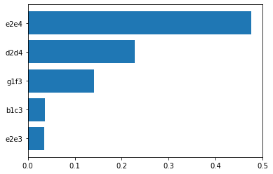

```python
plt.barh(range(opts)[::-1], probs[:opts])
ax = plt.gca()
ax.set_yticks(range(opts)[::-1])
ax.set_yticklabels(selected_moves[:opts])
```

```python
board = start_board
board.push_uci('e2e4')
board.push_uci('e7e5')
board.push_uci('f1c4')
board.push_uci('b8c6')
board.push_uci('d1h5')
x_scholar_atck = board_to_planes(board, normalize=tc.normalize, mode=mode)
board
```

[figure not shown]

```
[Text(0, 4, 'g7g6'),
```

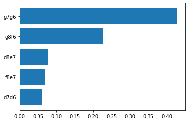

```python
pred = predict_single(net, x_scholar_atck, tc.select_policy_from_plane)

selected_moves, probs = policy_to_moves(board, pred[1][0])
plt.barh(range(opts)[::-1], probs[:opts])
ax = plt.gca()
ax.set_yticks(range(opts)[::-1])
ax.set_yticklabels(selected_moves[:opts])
```

```python
board.push(selected_moves[0])
board
```

[figure not shown]

### Performance on test dataset

```python
s_idcs_test, x_test, yv_test, yp_test, yplys_test, pgn_datasets_test = load_pgn_dataset(dataset_type='test', part_id=0,
                                                                               verbose=True, normalize=True)
test_data = get_data_loader(x_test, yv_test, yp_test, yplys_test, tc, shuffle=False)
```

```
2023-11-20 10:01:41 root[492] DEBUG loading: /data/SL/test/2021-01-12-14-14-42/lichess_db_crazyhouse_rated_2018-08_0.zip ...
2023-11-20 10:01:41 root[492] DEBUG
2023-11-20 10:01:42 root[492] INFO STATISTICS:
black_wins [443]
draws [5]
game_idx_end [1000]
game_idx_start [0]
number_selected_games [1000]
white_wins [552]
2023-11-20 10:01:42 root[492] INFO PARAMETERS:
batch_size [1000]
compression [b'lz4']
limit_nb_games [0]
max_nb_files [1]
min_elo_both [2000]
pgn_name [b'lichess_db_crazyhouse_rated_2018-08.pgn']
termination_conditions [b'Normal']
```

```python
if tc.framework == 'mxnet':
    metrics = metrics_gluon

evaluate_metrics(to.metrics, test_data, net, nb_batches=None, sparse_policy_label=tc.sparse_policy_label, ctx=ctx,
                 apply_select_policy_from_plane=tc.select_policy_from_plane, use_wdl=tc.use_wdl,
                 use_plys_to_end=tc.use_plys_to_end)
```

```
{'loss': tensor(1.7898, device='cuda:0'),
 'value_loss': tensor(0.8157, device='cuda:0'),
 'policy_loss': tensor(1.7996, device='cuda:0'),
 'value_acc_sign': tensor(0.6635, device='cuda:0'),
 'policy_acc': 0.48191745851652246,
 'wdl_loss': tensor(0.6205, device='cuda:0'),
 'wdl_acc': 0.6599063962558502,
 'plys_to_end_loss': tensor(0.0279, device='cuda:0')}
```

### Show result on mate-in-one problems

```python
s_idcs_mate, x_mate, yv_mate, yp_mate, yplys_mate, pgn_dataset_mate = load_pgn_dataset(dataset_type='mate_in_one', part_id=0,
                                                                              verbose=True, normalize=tc.normalize)
yplys_mate = np.ones(len(yv_mate))
mate_data = get_data_loader(x_mate, yv_mate, yp_mate, yplys_mate, tc, shuffle=False)
```

```
2023-11-20 10:01:50 root[492] DEBUG loading: /data/SL/mate_in_one/2021-01-12-14-14-59/lichess_db_crazyhouse_rated_2018-04_0.zip ...
2023-11-20 10:01:50 root[492] DEBUG
2023-11-20 10:01:50 root[492] INFO STATISTICS:
black_wins [430]
draws [0]
game_idx_end [1000]
game_idx_start [0]
number_selected_games [1000]
white_wins [570]
2023-11-20 10:01:50 root[492] INFO PARAMETERS:
batch_size [1000]
compression [b'lz4']
limit_nb_games [0]
max_nb_files [1]
min_elo_both [2000]
pgn_name [b'lichess_db_crazyhouse_rated_2018-04.pgn']
termination_conditions [b'Normal']
```

### Mate In One Performance

```python
evaluate_metrics(to.metrics, mate_data, net, nb_batches=None, sparse_policy_label=tc.sparse_policy_label, ctx=ctx,
                 apply_select_policy_from_plane=tc.select_policy_from_plane, use_wdl=tc.use_wdl,
                 use_plys_to_end=tc.use_plys_to_end)
```

```
{'loss': tensor(1.7475, device='cuda:0'),
 'value_loss': tensor(0.3448, device='cuda:0'),
 'policy_loss': tensor(1.7617, device='cuda:0'),
 'value_acc_sign': tensor(0.8840, device='cuda:0'),
 'policy_acc': 0.448,
 'wdl_loss': tensor(0.2957, device='cuda:0'),
 'wdl_acc': 0.884,
 'plys_to_end_loss': tensor(0.0404, device='cuda:0')}
```

### Show some example mate problems

```python
from IPython.core.interactiveshell import InteractiveShell
InteractiveShell.ast_node_interactivity = "all"
```

### Evaluate Performance

```python
def eval_pos(net, x_mate, yp_mate, verbose=False, select_policy_from_plane=False):

    board = planes_to_board(x_mate, normalized_input=tc.normalize, mode=mode)
    if verbose is True:
        print("{0}'s turn".format(chess.COLOR_NAMES[board.turn]))
        if board.uci_variant == "crazyhouse":
            print("black/white {0}".format(board.pockets))
    pred = predict_single(net, x_mate, select_policy_from_plane=select_policy_from_plane)

    true_move = policy_to_move(yp_mate, mirror_policy=board.turn==chess.BLACK)

    opts = 5
    pred_moves, probs = policy_to_moves(board, pred[1][0])
    pred_moves = pred_moves[:opts]

    legal_move_cnt = board.legal_moves.count()
    mate_move_cnt = str(board.legal_moves).count('#')

    is_mate_5_top = False

    for pred_move in pred_moves:
        board_5_top = deepcopy(board)
        board_5_top.push(pred_move)
        if board_5_top.is_checkmate() is True:
            is_mate_5_top = True
            break

    board.push(pred_moves[0])

    is_checkmate = False
    if board.is_checkmate() is True:
        is_checkmate = True

    filtered_pred = sorted(pred[1][0], reverse=True)

    if verbose is True:
        plt.barh(range(opts)[::-1], filtered_pred[:opts])
        ax = plt.gca()
        ax.set_yticks(range(opts)[::-1])
        ax.set_yticklabels(pred_moves)
        plt.title('True Move:' + str(true_move) +
                 '\nEval:' + str(pred[0][0]))
        plt.show()

    return pred, pred_moves, true_move, board, is_checkmate, is_mate_5_top, legal_move_cnt, mate_move_cnt
```

```python
nb_pos = len(x_mate)
mates_found = []
mates_5_top_found = []
legal_mv_cnts = []
mate_mv_cnts = []

for i in range(nb_pos):
    pred, pred_moves, true_move, board, is_mate, is_mate_5_top, legal_mv_cnt, mate_mv_cnt= eval_pos(net, x_mate[i], yp_mate[i], select_policy_from_plane=tc.select_policy_from_plane)
    mates_found.append(is_mate)
    legal_mv_cnts.append(legal_mv_cnt)
    mate_mv_cnts.append(mate_mv_cnt)
    mates_5_top_found.append(is_mate_5_top)
```

```python
np.array(mate_mv_cnts).mean()
```

```
1.623
```

```python
np.array(legal_mv_cnts).mean()
```

```
115.862
```

### Random Guessing Baseline

```python
np.array(mate_mv_cnts).mean() / np.array(legal_mv_cnts).mean()
```

```
0.014008044052407175
```

### Prediciton Performance

```python
print('mate_in_one_acc:', sum(mates_found) / nb_pos)
```

```
mate_in_one_acc: 0.582
```

```python
sum(mates_5_top_found) / nb_pos
```

```
0.925
```

```python
pgn_dataset_mate.tree()
```

```
Tree(nodes=(Node(disabled=True, name='/', nodes=(Node(disabled=True, icon='table', name='metadata (1001, 18) |…
```

```python
metadata = np.array(pgn_dataset_mate['metadata'])
metadata[0, :]
metadata[1, :]
```

```
array([b'Event', b'Site', b'Date', b'Round', b'White', b'Black',
       b'Result', b'BlackElo', b'BlackRatingDiff', b'BlackTitle',
       b'Termination', b'TimeControl', b'UTCDate', b'UTCTime', b'Variant',
       b'WhiteElo', b'WhiteRatingDiff', b''], dtype='|S128')
```

```
array([b'Rated Crazyhouse tournament https://lichess.org/tournament/EkplkgHV',
       b'https://lichess.org/6XtZaN95', b'2018.03.31', b'-', b'mrsjadk26',
       b'beatles_21', b'1-0', b'2101', b'-11', b'FM', b'Normal', b'180+0',
       b'2018.03.31', b'22:00:44', b'Crazyhouse', b'2158', b'+11', b''],
      dtype='|S128')
```

```python
site_mate = metadata[1:, 1]
```

```python
def clean_string(np_string):
    string = str(site_mate[i]).replace("b'", "")
    string = string.replace("'", "")
    string = string.replace('"', '')

    return string
```

```python
import chess.svg
from IPython.display import SVG, HTML
```

## Show the result of the first 17 examples

[output not shown]

[output cut: 48 more lines]

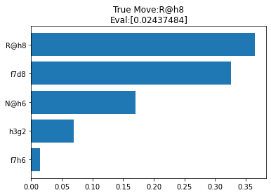

[figure not shown]

```
https://lichess.org/aGh9J93k
white's turn
black/white [CrazyhousePocket('qbp'), CrazyhousePocket('rbbbnnn')]
```

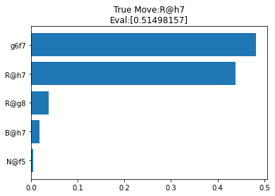

[figure not shown]

```
https://lichess.org/N65IVIw4
black's turn
black/white [CrazyhousePocket('qp'), CrazyhousePocket('bbbnnpppp')]
```

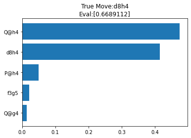

[figure not shown]

```
https://lichess.org/zr1Y3Yk0
black's turn
black/white [CrazyhousePocket('npp'), CrazyhousePocket('rbbnnp')]
```

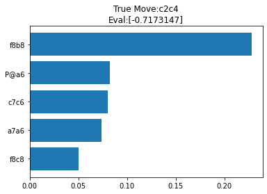

[figure not shown]

```
https://lichess.org/BcOhX1Tf
black's turn
black/white [CrazyhousePocket('pp'), CrazyhousePocket('qrrbbbnnpp')]
```

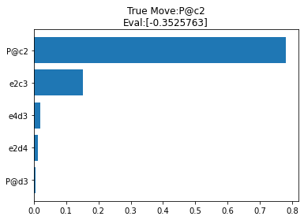

[figure not shown]

```
https://lichess.org/NgHPT61x
white's turn
black/white [CrazyhousePocket('qrnppp'), CrazyhousePocket('bnp')]
```

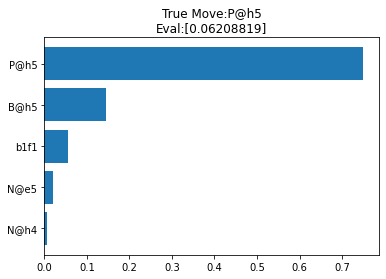

[figure not shown]

```
https://lichess.org/JaZSHQvm
black's turn
black/white [CrazyhousePocket('n'), CrazyhousePocket('pppp')]
```

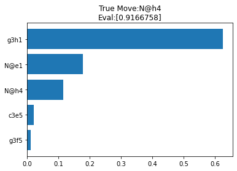

[figure not shown]

```
https://lichess.org/aEkH467l
white's turn
black/white [CrazyhousePocket('bpppp'), CrazyhousePocket('r')]
```

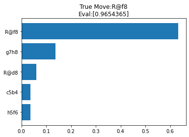

[figure not shown]

```
https://lichess.org/AXHqFp0W
white's turn
black/white [CrazyhousePocket('bbbp'), CrazyhousePocket('npp')]
```

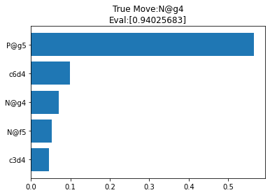

[figure not shown]

```
https://lichess.org/koKV9oe5
black's turn
black/white [CrazyhousePocket('p'), CrazyhousePocket('nppp')]
```

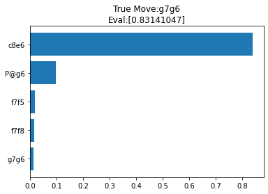

[figure not shown]

```
https://lichess.org/l30GAIip
black's turn
black/white [CrazyhousePocket('rbbnpp'), CrazyhousePocket('rp')]
```

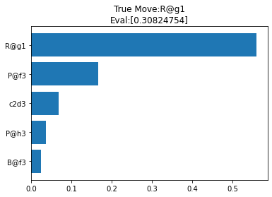

[figure not shown]

```
https://lichess.org/qSMyFbYs
white's turn
black/white [CrazyhousePocket('qnn'), CrazyhousePocket('bb')]
```

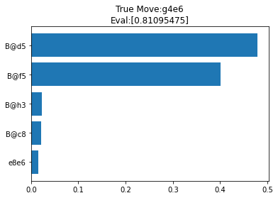

[figure not shown]

```
https://lichess.org/CUT8OfGV
white's turn
black/white [CrazyhousePocket('qrbb'), CrazyhousePocket('rnnnpp')]
```

[5 more figures not shown]

[figure not shown]

```python
for i in range(17):
    print(clean_string(site_mate[i]))
    pred, pred_moves, true_move, board, is_checkmate, is_mate_5_top, legal_move_cnt, mate_move_cnt = eval_pos(net, x_mate[i], yp_mate[i], verbose=True, select_policy_from_plane=tc.select_policy_from_plane)
    pred_move = pred_moves[0]
    pred_arrow = chess.svg.Arrow(pred_move.from_square, pred_move.to_square)
    SVG(data=chess.svg.board(board=board, arrows=[pred_arrow], size=400))
```

## Show examples where it failed

```
https://lichess.org/qSMyFbYs
white's turn
black/white [CrazyhousePocket('qnn'), CrazyhousePocket('bb')]
```

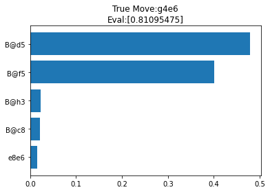

[figure not shown]

```
https://lichess.org/LsrFs69R
black's turn
black/white [CrazyhousePocket('pp'), CrazyhousePocket('qrrbnnpppp')]
```

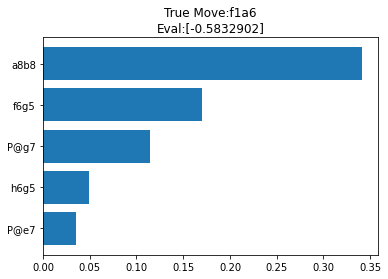

[figure not shown]

```
https://lichess.org/HuT31rHW
white's turn
black/white [CrazyhousePocket('rbn'), CrazyhousePocket('rbnppp')]
```

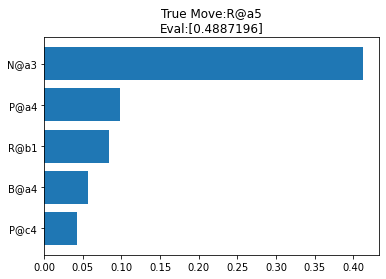

[figure not shown]

```
https://lichess.org/OUiO6Tty
white's turn
black/white [CrazyhousePocket('pp'), CrazyhousePocket('rp')]
```

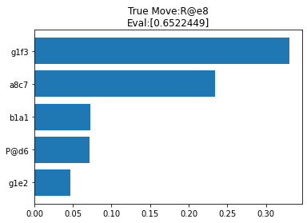

[figure not shown]

```
https://lichess.org/Agj9GlEo
white's turn
black/white [CrazyhousePocket('nnpppp'), CrazyhousePocket('p')]
```

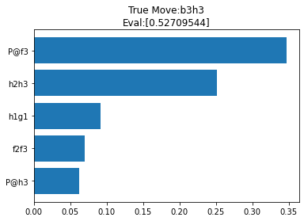

[figure not shown]

```
https://lichess.org/fZhepcrV
black's turn
black/white [CrazyhousePocket(''), CrazyhousePocket('nnppp')]
```

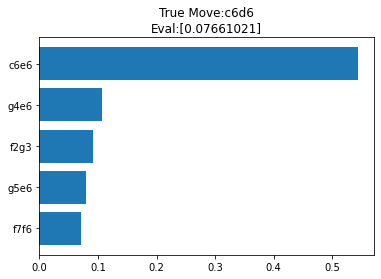

[figure not shown]

```
https://lichess.org/LzfAfvHl
white's turn
black/white [CrazyhousePocket('bbnnp'), CrazyhousePocket('rp')]
```

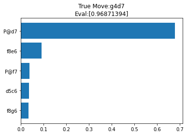

[figure not shown]

```
https://lichess.org/2Id1VEf7
white's turn
black/white [CrazyhousePocket('qnnpp'), CrazyhousePocket('n')]
```

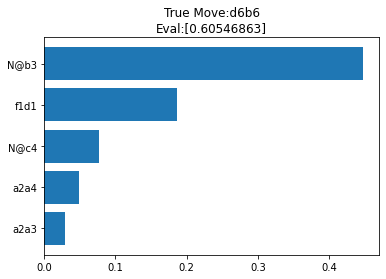

[figure not shown]

```
https://lichess.org/2SkoxX5
black's turn
black/white [CrazyhousePocket(''), CrazyhousePocket('rbnn')]
```

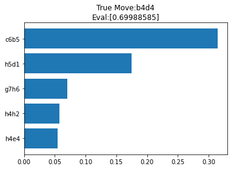

[figure not shown]

```
https://lichess.org/w7G5eMEJ
black's turn
black/white [CrazyhousePocket('bp'), CrazyhousePocket('nnnp')]
```

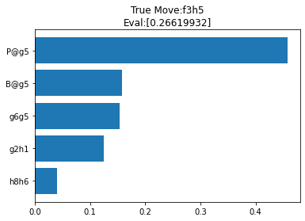

[figure not shown]

```
https://lichess.org/04SIAyOM
white's turn
black/white [CrazyhousePocket('b'), CrazyhousePocket('nppp')]
```

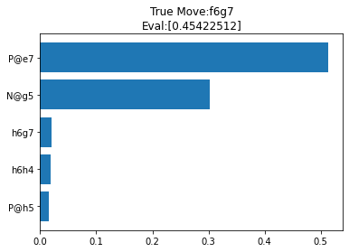

[figure not shown]

```
https://lichess.org/49HkGPC9
white's turn
black/white [CrazyhousePocket('pppp'), CrazyhousePocket('rbn')]
```

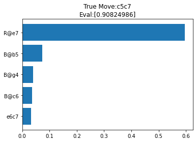

[figure not shown]

```
https://lichess.org/DOgF5Y2H
black's turn
black/white [CrazyhousePocket('qbnnnp'), CrazyhousePocket('bp')]
```

[3 more figures not shown]

[figure not shown]

```python
mate_missed = 0
for i in range(1000):
    pred, pred_moves, true_move, board, is_checkmate, is_mate_5_top, legal_move_cnt, mate_move_cnt = eval_pos(net, x_mate[i], yp_mate[i], verbose=False, select_policy_from_plane=tc.select_policy_from_plane)
    if is_mate_5_top is False:
        mate_missed += 1
        print(clean_string(site_mate[i]))
        pred, pred_moves, true_move, board, is_checkmate, is_mate_5_top, legal_move_cnt, mate_move_cnt = eval_pos(net, x_mate[i], yp_mate[i], verbose=True, select_policy_from_plane=tc.select_policy_from_plane)
        pred_move = pred_moves[0]
        pred_arrow = chess.svg.Arrow(pred_move.from_square, pred_move.to_square)
        SVG(data=chess.svg.board(board=board, arrows=[pred_arrow], size=400))
    if mate_missed == 15:
        break
```